# Access locations and times of Siberian Crane encounters

For this challenge, you will use a database called the [Global Biodiversity Information Facility (GBIF)](https://www.gbif.org/). GBIF is compiled from species observation data all over the world, and includes everything from museum specimens to photos taken by citizen scientists in their backyards.

**Explore GBIF:** Before your get started, go to the [GBIF occurrences search page](https://www.gbif.org/occurrence/search) and explore the data.

See also:

- [Crane Maps](https://github.com/byandell-envsys/craneMaps)
- [Sandhill Crane](https://github.com/earthlab-education/species-distribution-coding-challenge-byandell/blob/main/notebooks/sandhill_crane.qmd)

> **Contribute to open data**

> You can get your own observations added to GBIF using [iNaturalist](https://www.inaturalist.org/)!

### Set up your code to prepare for download

We will be getting data from a source called [GBIF (Global Biodiversity Information Facility)](https://www.gbif.org/). We need a package called `pygbif` to access the data, which may not be included in your environment. Install it by running the cell below:

```python
conda list pygbif
```

```python
%pip install -q -e ..
```

```python
from landmapyr.initial import create_data_dir, robust_code
from landmapyr.gbif import gbif_credentials, gbif_species_key
from landmapyr.gbif import download_gbif, load_gbif, gbif_monthly
from landmapyr.gbif import ecoregions, join_ecoregions_monthly
from landmapyr.gbif import count_by_ecoregions
from landmapyr.gbif import simplify_ecoregions_gdf, join_occurrence
```

**Import packages:** In the imports cell, we’ve included some packages that you will need. Add imports for packages that will help you:

- Work with reproducible file paths
- Work with tabular data

```python
robust_code()
data_dir = create_data_dir('species')
gbif_dir = create_data_dir('species/gbif_siberian')
gbif_dir
```

```
'/Users/brianyandell/earth-analytics/data/species/gbif_siberian'
```

### Register and log in to GBIF

You will need a [GBIF account](https://www.gbif.org/) to complete this challenge. You can use your GitHub account to authenticate with GBIF. Then, run the following code to save your credentials on your computer.

> **Warning**

> Your email address **must** match the email you used to sign up for GBIF!

> **Tip**

> If you accidentally enter your credentials wrong, you can set `reset_credentials=True` instead of `reset_credentials=False`. Look to top of screen for entry of credentials.

```python
gbif_credentials(False)
```

### Get the species key

> ** Your task**
> 1. Replace the `species_name` with the name of the species you want to look up
> 2. Run the code to get the species key

```python
species_name, species_key = gbif_species_key('grus leucogeranus')
species_name, species_key
```

```
('Grus leucogeranus', 2474961)
```

### Download data from GBIF

```python
gbif_path = download_gbif(gbif_dir, species_key, year=None)
gbif_path
```

```
'/Users/brianyandell/earth-analytics/data/species/gbif_siberian/0001177-250227182400228.zip'
```

```
INFO:Your download key is 0001177-250227182400228
INFO:Download file size: 171492 bytes
INFO:On disk at /Users/brianyandell/earth-analytics/data/species/gbif_siberian/0001177-250227182400228.zip
```

### Load the GBIF data into Python

**Load GBIF data:**

You can use the following code to look at the beginning of your file:

I copied from [Lauren Alexandra](https://github.com/lauren-alexandra/lauren-alexandra.github.io/blob/main/willow-flycatcher-distribution/willow-flycatcher-distribution.ipynb) and Lauren Gleason

```python
gbif_df = load_gbif(gbif_path)
print(gbif_df.head())
```

```
          countryCode stateProvince  decimalLatitude  decimalLongitude  month  \
gbifID
985829831          IN     Rajasthan        27.161905         77.522800    2.0
979229641          CN       Jiangxi        28.870571        116.433170   11.0
978902062          IR    Mazandaran        36.667110         52.550186   11.0
978782158          IN     Rajasthan        27.161905         77.522800    1.0
977810003          IN     Rajasthan        27.161905         77.522800    1.0

             year
gbifID
985829831  1991.0
979229641  1988.0
978902062  2011.0
978782158  1991.0
977810003  1992.0
```

## Convert GBIF data to a GeoDataFrame by Month

```python
monthly_gdf = gbif_monthly(gbif_df)
monthly_gdf
```

| gbifID | year | month | geometry |
| --- | --- | --- | --- |
| 985829831 | 1991.0 | 2.0 | POINT (77.5228 27.1619) |
| 979229641 | 1988.0 | 11.0 | POINT (116.43317 28.87057) |
| 978902062 | 2011.0 | 11.0 | POINT (52.55019 36.66711) |
| 978782158 | 1991.0 | 1.0 | POINT (77.5228 27.1619) |
| 977810003 | 1992.0 | 1.0 | POINT (77.5228 27.1619) |
| ... | ... | ... | ... |
| 1019036144 | 1983.0 | 6.0 | POINT (-90 43.75) |
| 1019036117 | 1983.0 | 6.0 | POINT (-90 43.75) |
| 1019036092 | 1983.0 | 6.0 | POINT (-90 43.75) |
| 1019036069 | 1983.0 | 6.0 | POINT (-90 43.75) |
| 1019035937 | 1983.0 | 6.0 | POINT (-90 43.75) |

2936 rows × 3 columns

### Download and save ecoregion boundaries

Ecoregions represent boundaries formed by biotic and abiotic conditions: geology, landforms, soils, vegetation, land use, wildlife, climate, and hydrology.

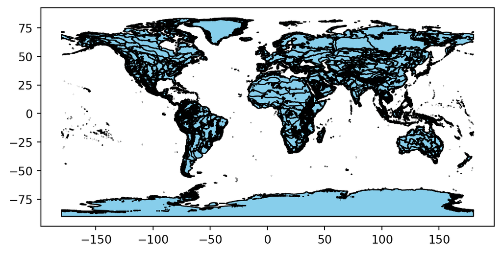

Figure 1

```python
ecoregions_gdf = ecoregions(data_dir)
ecoregions_gdf.plot(edgecolor='black', color='skyblue')
```

```python
%%bash
find ~/earth-analytics/data/species -name '*.shp'
```

```python
%store ecoregions_gdf monthly_gdf
```

```
Stored 'ecoregions_gdf' (GeoDataFrame)
Stored 'monthly_gdf' (GeoDataFrame)
```

Identify the ecoregion for each observation

```python
gbif_ecoregion_gdf = join_ecoregions_monthly(ecoregions_gdf, monthly_gdf)
gbif_ecoregion_gdf
```

| ecoregion | year | month | name |
| --- | --- | --- | --- |
| 5 | 2015.0 | 3.0 | Al-Hajar foothill xeric woodlands and shrublands |
| 5 | 2015.0 | 3.0 | Al-Hajar foothill xeric woodlands and shrublands |
| 5 | 2014.0 | 7.0 | Al-Hajar foothill xeric woodlands and shrublands |
| 5 | 2017.0 | 12.0 | Al-Hajar foothill xeric woodlands and shrublands |
| 8 | NaN | NaN | Alashan Plateau semi-desert |
| ... | ... | ... | ... |
| 802 | 2023.0 | 1.0 | Yellow Sea saline meadow |
| 802 | 2018.0 | 1.0 | Yellow Sea saline meadow |
| 802 | 2015.0 | 2.0 | Yellow Sea saline meadow |
| 802 | 2018.0 | 1.0 | Yellow Sea saline meadow |
| 802 | 2015.0 | 1.0 | Yellow Sea saline meadow |

2269 rows × 3 columns

Count the observations in each ecoregion each decade and month

```python
occurrence_month_df = count_by_ecoregions(gbif_ecoregion_gdf,
                        'ecoregion', 'name', 'month')
occurrence_month_df
```

| ecoregion | month | occurrences | norm_occurrences |
| --- | --- | --- | --- |
| 5 | 3.0 | 2 | 0.098214 |
| 24 | 5.0 | 6 | 0.156250 |
|  | 9.0 | 2 | 0.142857 |
| 53 | 3.0 | 9 | 0.098214 |
| 74 | 1.0 | 3 | 0.016181 |
| ... | ... | ... | ... |
| 758 | 5.0 | 20 | 0.132275 |
|  | 6.0 | 16 | 0.066253 |
| 802 | 1.0 | 4 | 0.021575 |
|  | 2.0 | 3 | 0.025840 |
|  | 12.0 | 2 | 0.013605 |

78 rows × 2 columns

```python
occurrence_decade_df = count_by_ecoregions(gbif_ecoregion_gdf,
                        'ecoregion', 'name', 'decade')
occurrence_decade_df
```

| ecoregion | decade | occurrences | norm_occurrences |
| --- | --- | --- | --- |
| 5 | 2010.0 | 4 | 0.026250 |
| 24 | 2010.0 | 4 | 0.030000 |
|  | 2020.0 | 3 | 0.013895 |
| 51 | 2010.0 | 2 | 0.026250 |
| 53 | 2020.0 | 9 | 0.016211 |
| 74 | 2010.0 | 2 | 0.013125 |
|  | 2020.0 | 6 | 0.024316 |
| 107 | 2000.0 | 4 | 0.005340 |
|  | 2010.0 | 53 | 0.028393 |
|  | 2020.0 | 90 | 0.029775 |
| 134 | 2010.0 | 3 | 0.008750 |
|  | 2020.0 | 15 | 0.027018 |
| 140 | 2010.0 | 2 | 0.021000 |
|  | 2020.0 | 3 | 0.019453 |
| 154 | 1980.0 | 12 | 0.001560 |
|  | 1990.0 | 9 | 0.001044 |
|  | 2000.0 | 19 | 0.006342 |
|  | 2010.0 | 509 | 0.068170 |
|  | 2020.0 | 431 | 0.035647 |
| 198 | 2010.0 | 19 | 0.033250 |
|  | 2020.0 | 11 | 0.011888 |
| 321 | 1910.0 | 2 | 0.138889 |
|  | 1980.0 | 8 | 0.028309 |
|  | 2000.0 | 4 | 0.036345 |
|  | 2010.0 | 8 | 0.029167 |
|  | 2020.0 | 14 | 0.031521 |
| 350 | 2010.0 | 2 | 0.005833 |
|  | 2020.0 | 16 | 0.028819 |
| 445 | 2000.0 | 5 | 0.029737 |
|  | 2010.0 | 24 | 0.057273 |
|  | 2020.0 | 4 | 0.005895 |
| 476 | 2010.0 | 24 | 0.026250 |
| 491 | 2010.0 | 9 | 0.020543 |
|  | 2020.0 | 14 | 0.019735 |
| 493 | 1990.0 | 12 | 0.030303 |
|  | 2000.0 | 2 | 0.014538 |
|  | 2010.0 | 13 | 0.037917 |
| 615 | 2010.0 | 2 | 0.026250 |
| 644 | 2010.0 | 83 | 0.026250 |
| 677 | 2020.0 | 4 | 0.016211 |
| 713 | 2000.0 | 8 | 0.035684 |
|  | 2010.0 | 18 | 0.032216 |
|  | 2020.0 | 18 | 0.019895 |
| 716 | 2010.0 | 9 | 0.001327 |
|  | 2020.0 | 347 | 0.031602 |
| 744 | 2010.0 | 2 | 0.026250 |
| 757 | 1970.0 | 17 | 0.012903 |
|  | 1980.0 | 90 | 0.029587 |
|  | 1990.0 | 138 | 0.040469 |
|  | 2000.0 | 65 | 0.054869 |
| 758 | 1980.0 | 47 | 0.037420 |
|  | 1990.0 | 17 | 0.012074 |
| 802 | 2010.0 | 8 | 0.042000 |
|  | 2020.0 | 2 | 0.006484 |

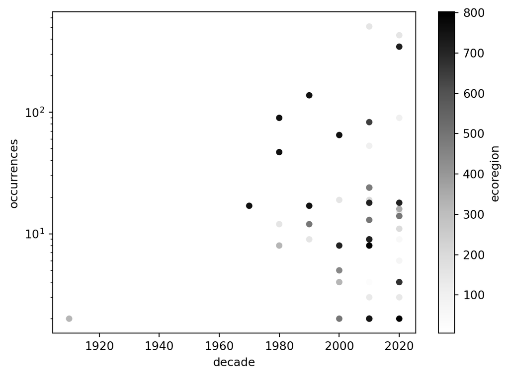

Figure 2

```python
# plot to check distributions
occurrence_decade_df.reset_index().plot.scatter(
    x='decade', y='occurrences', c='ecoregion',
    logy=True
)
```

Create a simplified GeoDataFrame for plot

```python
ecoregions_gdf = simplify_ecoregions_gdf(ecoregions_gdf)
ecoregions_gdf
```

| ecoregion | name | area | geometry |
| --- | --- | --- | --- |
| 0 | Adelie Land tundra | 0.038948 | MULTIPOLYGON EMPTY |
| 1 | Admiralty Islands lowland rain forests | 0.170599 | POLYGON ((16411777.375 -229101.376, 16384825.7... |
| 2 | Aegean and Western Turkey sclerophyllous and m... | 13.844952 | MULTIPOLYGON (((3391149.749 4336064.109, 33846... |
| 3 | Afghan Mountains semi-desert | 1.355536 | MULTIPOLYGON (((7369001.698 4093509.259, 73168... |
| 4 | Ahklun and Kilbuck Upland Tundra | 8.196573 | MULTIPOLYGON (((-17930832.005 8046779.358, -17... |
| ... | ... | ... | ... |
| 842 | Sulawesi lowland rain forests | 9.422097 | MULTIPOLYGON (((14113374.546 501721.962, 14128... |
| 843 | East African montane forests | 5.010930 | MULTIPOLYGON (((4298787.669 -137583.786, 42727... |
| 844 | Eastern Arc forests | 0.890325 | MULTIPOLYGON (((4267432.68 -493759.165, 428533... |
| 845 | Borneo montane rain forests | 9.358407 | MULTIPOLYGON (((13126956.393 539092.917, 13136... |
| 846 | Kinabalu montane alpine meadows | 0.352694 | POLYGON ((12981819.186 696445.445, 12997053.80... |

847 rows × 3 columns

### Mapping decadal distribution

```python
occurrence_gdf = join_occurrence(ecoregions_gdf, occurrence_decade_df)
occurrence_gdf
```

| ecoregion | decade | name | area | geometry | norm_occurrences |
| --- | --- | --- | --- | --- | --- |
| 5 | 2010.0 | Al-Hajar foothill xeric woodlands and shrublands | 4.099668 | POLYGON ((6264504.021 2842331.306, 6336024.085... | 0.026250 |
| 24 | 2010.0 | Amur meadow steppe | 15.118769 | MULTIPOLYGON (((15067649.194 6001589.024, 1503... | 0.030000 |
|  | 2020.0 | Amur meadow steppe | 15.118769 | MULTIPOLYGON (((15067649.194 6001589.024, 1503... | 0.013895 |
| 51 | 2010.0 | European Atlantic mixed forests | 48.383344 | MULTIPOLYGON (((-509089.943 6127087.807, -5328... | 0.026250 |
| 53 | 2020.0 | Azerbaijan shrub desert and steppe | 6.794797 | POLYGON ((5427403.54 5089371.081, 5512543.361 ... | 0.016211 |
| 74 | 2010.0 | Bohai Sea saline meadow | 1.187602 | MULTIPOLYGON (((13116898.113 4589071.254, 1319... | 0.013125 |
|  | 2020.0 | Bohai Sea saline meadow | 1.187602 | MULTIPOLYGON (((13116898.113 4589071.254, 1319... | 0.024316 |
| 107 | 2000.0 | Caspian Hyrcanian mixed forests | 5.604168 | MULTIPOLYGON (((5333143.547 4574764.516, 52538... | 0.005340 |
|  | 2010.0 | Caspian Hyrcanian mixed forests | 5.604168 | MULTIPOLYGON (((5333143.547 4574764.516, 52538... | 0.028393 |
|  | 2020.0 | Caspian Hyrcanian mixed forests | 5.604168 | MULTIPOLYGON (((5333143.547 4574764.516, 52538... | 0.029775 |
| 134 | 2010.0 | Central China Loess Plateau mixed forests | 37.104395 | MULTIPOLYGON (((13378649.084 5076474.672, 1331... | 0.008750 |
|  | 2020.0 | Central China Loess Plateau mixed forests | 37.104395 | MULTIPOLYGON (((13378649.084 5076474.672, 1331... | 0.027018 |
| 140 | 2010.0 | Central Korean deciduous forests | 10.616297 | MULTIPOLYGON (((14084109.316 4498884.57, 14068... | 0.021000 |
|  | 2020.0 | Central Korean deciduous forests | 10.616297 | MULTIPOLYGON (((14084109.316 4498884.57, 14068... | 0.019453 |
| 154 | 1980.0 | Changjiang Plain evergreen forests | 41.203493 | MULTIPOLYGON (((13613475.56 3473108.645, 13581... | 0.001560 |
|  | 1990.0 | Changjiang Plain evergreen forests | 41.203493 | MULTIPOLYGON (((13613475.56 3473108.645, 13581... | 0.001044 |
|  | 2000.0 | Changjiang Plain evergreen forests | 41.203493 | MULTIPOLYGON (((13613475.56 3473108.645, 13581... | 0.006342 |
|  | 2010.0 | Changjiang Plain evergreen forests | 41.203493 | MULTIPOLYGON (((13613475.56 3473108.645, 13581... | 0.068170 |
|  | 2020.0 | Changjiang Plain evergreen forests | 41.203493 | MULTIPOLYGON (((13613475.56 3473108.645, 13581... | 0.035647 |
| 198 | 2010.0 | Daurian forest steppe | 26.252795 | POLYGON ((13320358.199 6772264.491, 13349680.3... | 0.033250 |
|  | 2020.0 | Daurian forest steppe | 26.252795 | POLYGON ((13320358.199 6772264.491, 13349680.3... | 0.011888 |
| 321 | 1910.0 | Huang He Plain mixed forests | 43.295555 | POLYGON ((13332332.499 4862491.773, 13335344.1... | 0.138889 |
|  | 1980.0 | Huang He Plain mixed forests | 43.295555 | POLYGON ((13332332.499 4862491.773, 13335344.1... | 0.028309 |
|  | 2000.0 | Huang He Plain mixed forests | 43.295555 | POLYGON ((13332332.499 4862491.773, 13335344.1... | 0.036345 |
|  | 2010.0 | Huang He Plain mixed forests | 43.295555 | POLYGON ((13332332.499 4862491.773, 13335344.1... | 0.029167 |
|  | 2020.0 | Huang He Plain mixed forests | 43.295555 | POLYGON ((13332332.499 4862491.773, 13335344.1... | 0.031521 |
| 350 | 2010.0 | Jian Nan subtropical evergreen forests | 59.745023 | MULTIPOLYGON (((13366375.518 3078256.552, 1334... | 0.005833 |
|  | 2020.0 | Jian Nan subtropical evergreen forests | 59.745023 | MULTIPOLYGON (((13366375.518 3078256.552, 1334... | 0.028819 |
| 445 | 2000.0 | Mongolian-Manchurian grassland | 103.136132 | POLYGON ((13399045.827 6690406.546, 13411644.4... | 0.029737 |
|  | 2010.0 | Mongolian-Manchurian grassland | 103.136132 | POLYGON ((13399045.827 6690406.546, 13411644.4... | 0.057273 |
|  | 2020.0 | Mongolian-Manchurian grassland | 103.136132 | POLYGON ((13399045.827 6690406.546, 13411644.4... | 0.005895 |
| 476 | 2010.0 | Nihonkai evergreen forests | 2.172062 | MULTIPOLYGON (((14838329.599 4319227.511, 1484... | 0.026250 |
| 491 | 2010.0 | Northeast China Plain deciduous forests | 26.069601 | MULTIPOLYGON (((13285446.855 5177582.449, 1327... | 0.020543 |
|  | 2020.0 | Northeast China Plain deciduous forests | 26.069601 | MULTIPOLYGON (((13285446.855 5177582.449, 1327... | 0.019735 |
| 493 | 1990.0 | Northeast Siberian coastal tundra | 54.583079 | MULTIPOLYGON (((17977352.099 10838116.421, 179... | 0.030303 |
|  | 2000.0 | Northeast Siberian coastal tundra | 54.583079 | MULTIPOLYGON (((17977352.099 10838116.421, 179... | 0.014538 |
|  | 2010.0 | Northeast Siberian coastal tundra | 54.583079 | MULTIPOLYGON (((17977352.099 10838116.421, 179... | 0.037917 |
| 615 | 2010.0 | Selenge-Orkhon forest steppe | 28.090333 | MULTIPOLYGON (((10550560.509 6345569.594, 1061... | 0.026250 |
| 644 | 2010.0 | South China-Vietnam subtropical evergreen forests | 19.600028 | MULTIPOLYGON (((12348762.017 2258424.919, 1235... | 0.026250 |
| 677 | 2020.0 | Southern Korea evergreen forests | 1.449664 | MULTIPOLYGON (((14067544.103 4086271.62, 14056... | 0.016211 |
| 713 | 2000.0 | Taiheiyo evergreen forests | 13.553387 | MULTIPOLYGON (((14748057.024 4038696.166, 1473... | 0.035684 |
|  | 2010.0 | Taiheiyo evergreen forests | 13.553387 | MULTIPOLYGON (((14748057.024 4038696.166, 1473... | 0.032216 |
|  | 2020.0 | Taiheiyo evergreen forests | 13.553387 | MULTIPOLYGON (((14748057.024 4038696.166, 1473... | 0.019895 |
| 716 | 2010.0 | Taiwan subtropical evergreen forests | 2.953675 | POLYGON ((13463176.55 2555136.408, 13437821.53... | 0.001327 |
|  | 2020.0 | Taiwan subtropical evergreen forests | 2.953675 | POLYGON ((13463176.55 2555136.408, 13437821.53... | 0.031602 |
| 744 | 2010.0 | Trans-Baikal conifer forests | 25.732184 | MULTIPOLYGON (((12494118.896 6222155.236, 1247... | 0.026250 |
| 757 | 1970.0 | Upper Gangetic Plains moist deciduous forests | 23.895360 | POLYGON ((8770042.323 3393768.842, 8910982.032... | 0.012903 |
|  | 1980.0 | Upper Gangetic Plains moist deciduous forests | 23.895360 | POLYGON ((8770042.323 3393768.842, 8910982.032... | 0.029587 |
|  | 1990.0 | Upper Gangetic Plains moist deciduous forests | 23.895360 | POLYGON ((8770042.323 3393768.842, 8910982.032... | 0.040469 |
|  | 2000.0 | Upper Gangetic Plains moist deciduous forests | 23.895360 | POLYGON ((8770042.323 3393768.842, 8910982.032... | 0.054869 |
| 758 | 1980.0 | Upper Midwest US forest-savanna transition | 15.481685 | MULTIPOLYGON (((-9686382.157 5638236.966, -973... | 0.037420 |
|  | 1990.0 | Upper Midwest US forest-savanna transition | 15.481685 | MULTIPOLYGON (((-9686382.157 5638236.966, -973... | 0.012074 |
| 802 | 2010.0 | Yellow Sea saline meadow | 0.517810 | POLYGON ((13451648.07 3834357.593, 13303152.21... | 0.042000 |
|  | 2020.0 | Yellow Sea saline meadow | 0.517810 | POLYGON ((13451648.07 3834357.593, 13303152.21... | 0.006484 |

#### Static Plot

[figure not shown]

Figure 3

```python
from landmapyr.plots import plot_occurrence
plot_occurrence(occurrence_gdf, 'decade', ncols=1)
```

#### Optional Dynamic Plot

```python
from landmapyr.hv_plots import hvplot_occurrence
occurrence_hvplot = hvplot_occurrence(occurrence_gdf, 'decade',
  title="Grus leucogeranus Siberian Crane Decadal Tracking")
# Save the plot
occurrence_hvplot.save('siberian-crane-decades.html', embed=True)
```

```
WARNING:W-1005 (FIXED_SIZING_MODE): 'fixed' sizing mode requires width and height to be set: figure(id='1da8b71a-a35e-4f98-a085-041c0be44a19', ...)
```

```python
occurrence_hvplot
```

```
<iframe src="siberian-crane-decades.html" width="100%" height="500px"
        style="border: none;"></iframe>
```

[interactive chart not shown]

If not shown, see Dynamic Images from Environmental Data Analytics Projects.